# 1.1 Vector Orientation

# 1.1 Vector Orientation

In our common phrase "x-y-plane" lies the convention that points are specified as ordered pairs $(x,y)$ with $x$ denoting its horizontal component and $y$ its vertical component. We rephrase this convention in terms of the **vectors** that point along the $x$ and $y$ axes, i.e.,

\begin{equation} \label{eq:exy} e_x = \begin{bmatrix}1 \\ 0\end{bmatrix} \and e_y = \begin{bmatrix}0 \\ 1\end{bmatrix} \end{equation}

respectively. We illustrate these vectors in Figure \ref{fig:orient} together with the combination

\begin{equation}\label{eq:firstu} u = \begin{bmatrix} 0.5 \\ 1.5 \end{bmatrix} = \begin{bmatrix} 0.5 \\ 0 \end{bmatrix} + \begin{bmatrix} 0 \\ 1.5 \end{bmatrix} = 0.5e_x + 1.5e_y \end{equation}

This sequence also serves as a first demonstration of both vector addition and scalar multiplication.

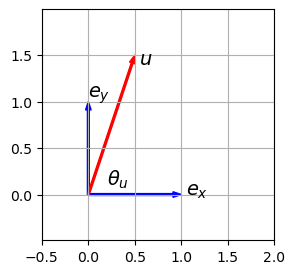

```python
# Draw and label three vectors and an angle
#%load_ext watermark
%matplotlib inline
import matplotlib.pyplot as plt     # the standard plot library (click on Help in the header to learn more)

plt.figure(figsize=(3,3))
plt.arrow(0,0,1,0,width=0.02,length_includes_head=True, color='b')
plt.text(1.05,0,'$e_x$',fontsize=14)
plt.text(0.2,0.1,'$\\theta_u$',fontsize=14)
plt.arrow(0,0,0,1,width=0.02,length_includes_head=True, color = 'b')
plt.text(0,1.05,'$e_y$',fontsize=14)
plt.arrow(0,0,0.5,1.5,width=0.02,length_includes_head=True, color='r')
plt.text(0.55,1.4,'$u$',fontsize=14)

plt.grid('on')
plt.axis('equal')
plt.axis([-.5, 2, -.5, 2]);
```

\begin{myfig}\label{fig:orient} The pair of blue unit-vectors, $\{e_x, e_y\}$ from (\ref{eq:exy}), specify our **orientation** in the sense that the second is **counterclockwise** from the first. Also any other vector in the plane may be written as a weighted sum of $e_x$ and $e_y$. For example, we graph the red $u$ vector of (\ref{eq:firstu}). \end{myfig}

Further examples of vector addition and scalar multiplication are

$$ \begin{bmatrix} 1 \\ 3\end{bmatrix} + \begin{bmatrix} 4 \\ 1\end{bmatrix} = \begin{bmatrix} 5 \\ 4\end{bmatrix} \and 6 \begin{bmatrix} 4 \\ 2\end{bmatrix} = \begin{bmatrix} 24 \\ 12\end{bmatrix}. $$

We will also make frequent use of the **polar** representation of points in the plane. Regarding the $u$ in Figure \ref{fig:orient} we write

\begin{equation}\label{eq:upol} u = \begin{bmatrix} 0.5 \\ 1.5 \end{bmatrix} = \|u\|\begin{bmatrix} \cos(\theta_u) \\ \sin(\theta_u) \end{bmatrix} \end{equation}

where $\theta_u$ is the counterclockwise angle that $u$ makes with $e_x$, and $\|u\|$ denotes the length, or **norm**, of $u$ in the pythagorean sense

\begin{equation}\label{eq:normdef} \|u\| \equiv \sqrt{u[0]^2 + u[1]^2} = \sqrt{10}/2 \end{equation}

where $u[0]$ and $u[1]$ are respectively the first and second elements of $u$.

The most common product of two vectors, $u$ and $v$, in the plane is the **inner product**. It is the sum of their elementwise products

\begin{equation} \label{eq:ipdef} u^T v \equiv \begin{bmatrix} u[0] & u[1] \end{bmatrix} \begin{bmatrix} v[0] \\ v[1] \end{bmatrix} = u[0]v[0] + u[1]v[1]. \end{equation}

As $u[j]v[j]=v[j]u[j]$ for each $j$ it follows that $u^Tv=v^Tu$. For example,

$$ \begin{bmatrix}10 & 2 \end{bmatrix} \begin{bmatrix} -3 \\ 5\end{bmatrix} = 10\cdot (-3) + 2\cdot 5 = -20. $$

So, the inner product of two vectors is a number. The superscript $T$ on the $u$ on the far left of (\ref{eq:ipdef}) stands for **transpose** and, when applied to a column yields a **row**. Columns are vertical and rows are horizontal and so we see, in (\ref{eq:ipdef}), that $u^T$ is $u$ laid on its side.

As, $u^Tu=u[0]^2+u[1]^2$, we recognize that the norm of a vector is the square root of its inner product with itself, i.e.,

\begin{equation} \label{eq:normdef2} \|u\| = (u^Tu)^{1/2} = \left(u[0]^2+u[1]^2\right)^{1/2}. \end{equation}

Let's compute the inner product of the two vectors illustrated in Figure \ref{fig:mf1}.

We write them in their Cartesian and polar forms

$$ u = \begin{bmatrix}u[0] \\ u[1]\end{bmatrix} = \begin{bmatrix}1 \\ 3\end{bmatrix} = \|u\| \begin{bmatrix} \cos(\theta_u) \\ \sin(\theta_u) \end{bmatrix} \and v = \begin{bmatrix}v[0] \\ v[1]\end{bmatrix} = \begin{bmatrix}4 \\ 1\end{bmatrix} = \|v\| \begin{bmatrix} \cos(\theta_v) \\ \sin(\theta_v) \end{bmatrix} $$

and on substitution into (\ref{eq:ipdef}) find

\begin{equation} \eqalign{ u^Tv &= u[0]v[0] + u[1]v[1] \cr &= \|u\|\|v\|(\cos(\theta_u)\cos(\theta_v)+ \sin(\theta_u)\sin(\theta_v)) \cr &= \|u\|\|v\|\cos(\theta_u-\theta_v) \cr &= \|u\|\|v\|\cos(\theta). \cr} \label{eq:cauchyexact} \end{equation}

where $\theta=\theta_u-\theta_v$. We interpret (\ref{eq:cauchyexact}) by saying that the inner product of two vectors is proportional to the cosine of the angle between them. When this angle is $\pi/2$ we say that the two vectors are **perpendicular** to one another.

On taking the absolute value of each side of (\ref{eq:cauchyexact}) we arrive at the **Cauchy-Schwarz inequality**

\begin{equation} \boxed{|u^Tv| \le \|u\|\|v\|.} \label{eq:cauchyschwarz} \end{equation}

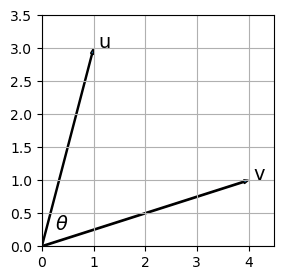

```python
# Draw and label two vectors
%matplotlib inline
import matplotlib.pyplot as plt

plt.figure(figsize=(3,3))
plt.arrow(0,0,4,1,width=0.02,length_includes_head=True)
plt.text(4.1,1,'v',fontsize=14)
plt.arrow(0,0,1,3,width=0.02,length_includes_head=True)
plt.text(1.1,3,'u',fontsize=14)
plt.text(0.25,0.25,'$\\theta$',fontsize=14)
plt.grid('on')
plt.axis([0, 4.5, 0, 3.5]);
```

\begin{myfig}\label{fig:mf1} The angle between two vectors. \end{myfig}

\begin{exercise}\label{ex:arithmetic} Given $$ x = \begin{bmatrix} 2 \\ 1 \end{bmatrix} \and y = \begin{bmatrix} 3 \\ 4 \end{bmatrix} $$ complete the code cell below to compute and display **(a)** $x+y$, **(b)** $\|x\|$, **(c)** $\|y\|$, **(d)** $x^Ty$, and **(e)** the angle between $x$ and $y$. \end{exercise}

```python
# vector and print operations in python
import numpy as np      # import the library of numerical functions (click Help in our header to get help with numpy)
# %watermark -p numpy     # checking versions
# %watermark -p matplotlib

x = np.array([2,1])    # vectors are called arrays in python
y = np.array([3,4])
print('x + y is ', x+y)
normx = np.sqrt(x[0]**2 + x[1]**2)    # to take powers we use ** in python
print('norm of x is ', round(normx,3))
# normy =
#print('norm of y is ', normy)
ip = np.dot(x, y)    # the inner product is also known as the dot product
print(' x^Ty is ', ip )
#angle =    # use np.arccos and equation 7
# print( ' angle between x and y is ', angle)
```

```
x + y is  [5 5]
norm of x is  2.236
 x^Ty is  10
```

\begin{exercise}\label{ex:orth2} Find a vector perpendicular to $[1,1]^T$. Use the code cell below to compute and display their inner product. \end{exercise}

```python
# Your solution here
import numpy as np
print(np.dot([1,1],[1,-1]))
```

```
0
```

We next explore the geometry of the sum of two vectors

\begin{equation}\label{eq:uvp} u = \begin{bmatrix} a \\ c \end{bmatrix} \and v = \begin{bmatrix} b \\ d \end{bmatrix} \end{equation}

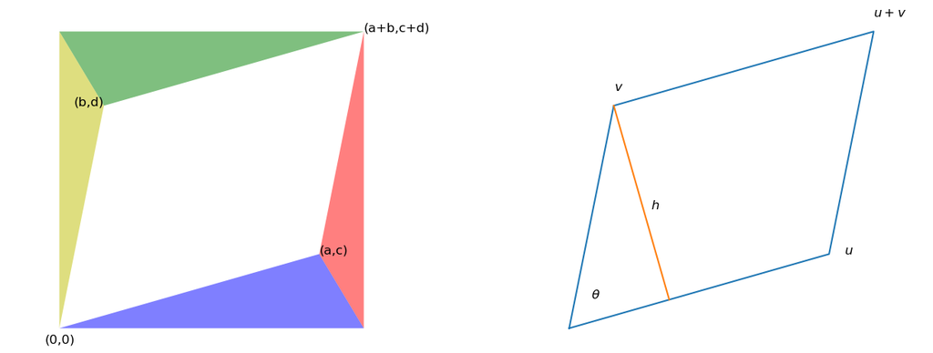

```python
# vector addition as a parallelogram
%matplotlib inline
import numpy as np
import matplotlib.pyplot as plt

fig, (ax1, ax2) = plt.subplots(1, 2)
plt.subplots_adjust(right=2, top=1, wspace=0.25)

a = 1.75
b = 0.3
c = 0.5
d = 1.5

ax1.fill([0, a+b, a, 0], [0, 0, c, 0], 'b', alpha = 0.5)
ax1.fill([a, a+b, a+b, a], [c, 0, c+d, c], 'r', alpha = 0.5)
ax1.fill([0, b, a+b, 0], [c+d, d, c+d, c+d], 'g', alpha = 0.5)
ax1.fill([0, b, 0, 0], [0, d, c+d, 0], 'y', alpha = 0.5)

ax1.text(0-.1, 0-.1, '(0,0)', fontsize=12)
ax1.text(a,c,'(a,c)', fontsize=12)
ax1.text(a+b,c+d,'(a+b,c+d)', fontsize=12)
ax1.text(b-.2,d,'(b,d)', fontsize=12)

ax1.axis('equal')
ax1.axis('off')

ax2.plot([0,a, a+b, b, 0],[0,c,c+d,d,0])
# find height
u = np.array([a,c])
v = np.array([b,d])
pv = np.dot(u,v)*u/np.dot(u,u)
ax2.plot([pv[0], v[0]], [pv[1], v[1]])
ax2.text(0.15,0.2,'$\\theta$', fontsize=12)
ax2.text(a+0.1,c,'$u$', fontsize=12)
ax2.text(b,d+0.1,'$v$', fontsize=12)
ax2.text(a+b,c+d+0.1,'$u+v$', fontsize=12)
ax2.text(0.55,0.8,'$h$', fontsize=12)

ax2.axis('equal')
ax2.axis('off');
```

\begin{myfig}\label{fig:mf2} The parallelogram associated with the sum the two vectors in (\ref{eq:uvp}). Each figure sets the stage for computing the area of the parallelogram. On the left we label the coordinates and see the parallelogram as the complement of 4 triangles within a rectangle. On the right we stress its angle and height.\end{myfig}

\begin{exercise}\label{ex:parallelogram} We compute the area of the parallelogram in Figure \ref{fig:mf2} by two distinct means. Please remain in the domain of letters. (a) Using the left panel, subtract the 4 triangle areas from the area of large rectangle and arrive at $ad-bc$. (b) Using the right panel, use area = base times height = $\Vert u\Vert\Vert v\Vert\sin(\theta)$. (c) Reconcile these two formulas using the fact that $\theta=\theta_v-\theta_u$. \end{exercise}

Your solution here.

\begin{exercise}\label{ex:polarization} Please complete the markdown cell below and arrive at the **polarization formula** \begin{equation} \|x+y\|^2-\|x-y\|^2 = 4x^Ty, \end{equation} holds for all $x$ and $y$ in $\maR^2$. \end{exercise}

Your solution here.

\begin{equation} \eqalign{ \|x+y\|^2-\|x-y\|^2 &= (x+y)^T(x+y) - (x-y)^T(x-y) \\ &= (x^T+y^T)(x+y) - (x^T-y^T)(x-y) \\ &= \hbox{now FOIL both products and simplify} } \end{equation}

\begin{exercise}\label{ex:triangineq} Show that the **triangle inequality** \begin{equation} \|x+y\| \le \|x\| + \|y\| \end{equation} holds for all $x$ and $y$ in $\maR^2$. First sketch this for two concrete planar $x$ and $y$ and expound on the aptness of the name. Then, in the markdown cell below, expand $\|x+y\|^2$, invoke the Cauchy-Schwarz inequality, (\ref{eq:cauchyschwarz}), and finish with a square root. \end{exercise}

Your solution here.

Next Section: 1.2 Matrix Vector Multiplication